Antonio Di Carlo

Matricola 158459

# Fattori di rischio e mortalità negli Incidenti Stradali

Fondamenti di Scienza dei Dati e Laboratorio

## Introduzione e scelta del dataset

- Gli **incidenti stradali** rientrano tra le principali cause di *morte*
- I mezzi di trasporto sono fondamentali per la nostra *mobilità*
- Sensibilizzazione e consapevolezza dei *rischi*

## Entità degli incidenti stradali

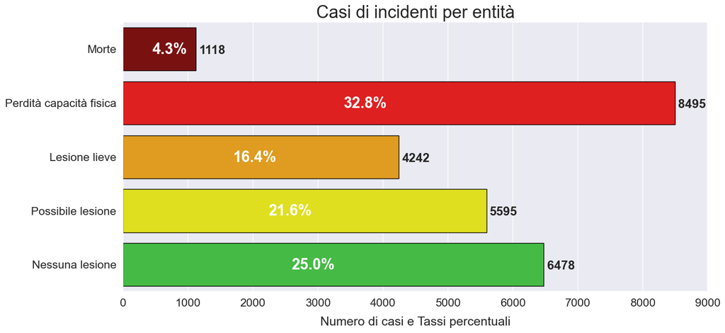

## Uso della cintura di sicurezza

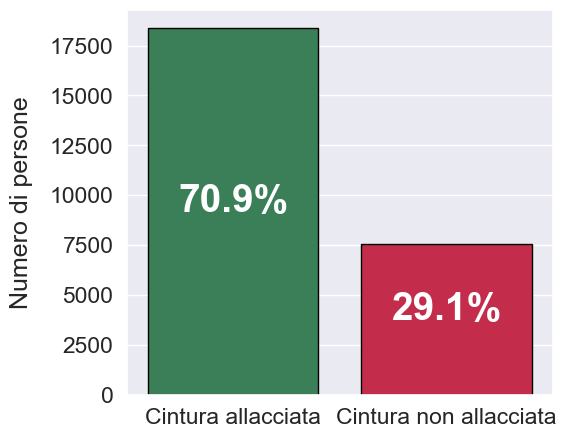

### Ora che abbiamo distinto i due gruppi torniamo nel dettaglio...

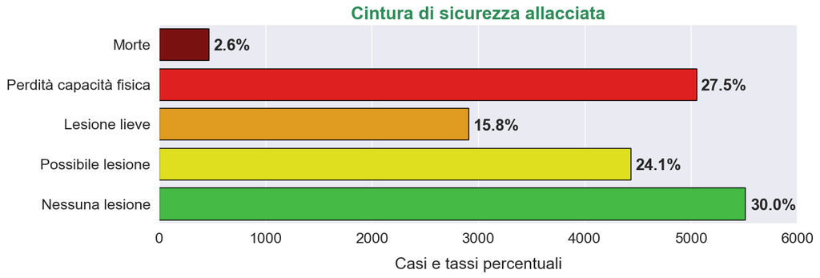

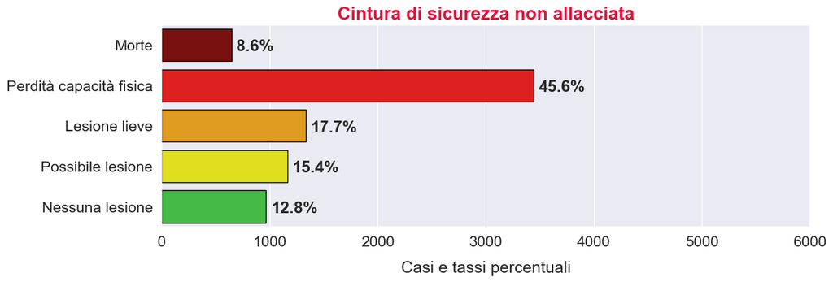

## Quindi abbiamo osservato che:

### **Non allacciare** la cintura di sicurezza comporta...

- ☠️Aumento del rischio di **morte** di 3.3 volte
- 🧑‍🦽Aumento del rischio di **perdita di capacità fisica** di 1.7 volte

### **Allacciare** la cintura di sicurezza comporta...

- 🙂Aumento della probabilità di **rimanere illesi** di 2.3 volte

## Mortalità in base a sesso ed età

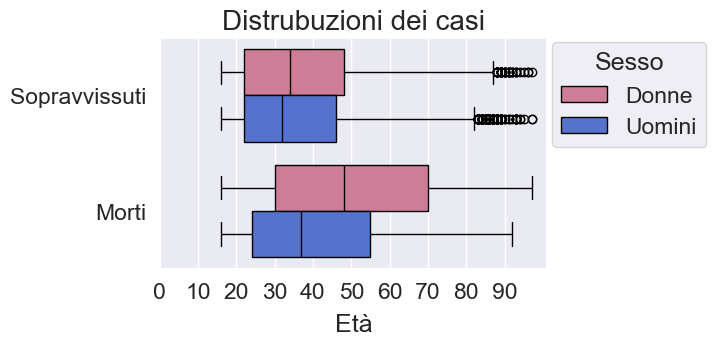

### Il grafico mostra che all'aumentare dell'età abbiamo:

- Un aumento della mortalità di entrambi i sessi
- Una maggiore vulnerabilità delle **donne**

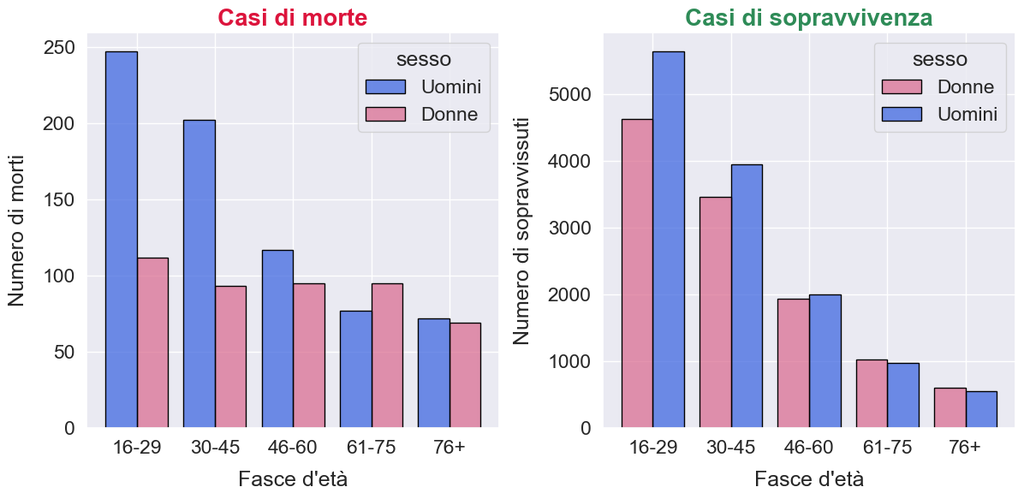

## Dai dati emerge che per le fasce d'età analizzate:

### I tassi di mortalità degli **uomini** sono...

- 16-29 anni: **4.2%**
- 30-45 anni: **4.8%**
- 46-60 anni: **5.5%**
- 61-75 anni: **7.3%**
- Oltre i 76 anni: **11.5%**

### I tassi di mortalità delle **donne** sono...

- 16-29 anni: **2.3%**
- 30-45 anni: **2.6%**
- 46-60 anni: **4.6%**
- 61-75 anni: **8.4%**
- Oltre i 76 anni: **10.2%**

## In conclusione abbiamo:

### Constatato l'importanza dell'uso della cintura di sicurezza con:

- *Diminuzione* del rischio di **morte** di **3.3** volte
- *Diminuzione* del rischio di **perdita di capacità fisica** di **1.7** volte
- *Aumento* della probabilità di rimanere **illesi** di **2.3** volte

### Osservato l'aumento della mortalità per sesso ed età

### Riscontrato che il tasso di mortalità è...

- *Tra i 16 e i 45 anni:* **1.8** volte maggiore per gli **uomini**
- *Tra i 46 e i 60 anni:* **1.2** volte maggiore per gli **uomini**
- *Tra i 61 e i 75 anni:* **1.1** volte maggiore per le **donne**
- *Oltre i 76 anni:* **1.1** volte maggiore per gli **uomini**

# Fine della presentazione

Link a **Kaggle** per il dataset utilizzato:  
https://www.kaggle.com/datasets/mexwell/influences-on-accident-fatalities

Grazie per l'attenzione